# Homework #2 Programming Assignment Solution

Most of functions in this homework are saved in the following notebooks.

Basic Functions.ipynb

Non-binary Huffman Coding.ipynb

Tunstall Coding.ipynb

```julia
using NBInclude
nbinclude("Basic Functions.ipynb");
nbinclude("Non-binary Huffman Coding.ipynb");
nbinclude("Tunstall Coding.ipynb");
using PyPlot
```

[output not shown]

## Problem 1

#### Write a program for a function $\texttt{daryHuffman(pmf, d)}$ that takes a probability vector $\texttt{pmf}$ and the size of alphabet $d$ as inputs, and outputs a $d$-ary Huffman code. For example,

#### $$\tt ["0","1","20","21","22"] = daryHuffman([0.6,0.2,0.1,0.05,0.05],3)$$

#### (a) Run the program for $\texttt{pmf} = \{0.6, 0.3, 0.1\}$ with $d=3$ and compute the average length of the resulting Huffman code.

```julia
pmf = [0.6, 0.3, 0.1]
code = daryHuffman(pmf, 3)
```

```
3-element Array{String,1}:
 "0"
 "1"
 "2"
```

```julia
avgLength(code, pmf)
```

```
1.0
```

#### (b) Consider block lengths $n=2,3,5$. For each block length, find the ternary Huffman code and the average length per symbol.

```julia
pmf1 = pmf
print("==========================================================================================\n")
print("pmf1: ", pmf1, "\n")
print("entropy of base 3: ", entropy(pmf1)/log2(3), "\n")
pmfn = copy(pmf1)
for n in [2,3,5]
    pmfn = blockPmf(pmf1, n, pmfn)
    code = daryHuffman(pmfn, 3)
    avg_length = avgLength(code, pmfn)
    print("------------------------------\n")
    print("For the block length = ", n, ", \n")
    print("The entropy of base 3 is                   ", n*entropy(pmf1)/log2(3), "\n")
    print("The average length of Huffman code is \t   ", avg_length, "\n")
end
```

```
==========================================================================================
pmf1: [0.6,0.3,0.1]
entropy of base 3: 0.8173454221465103
------------------------------
For the block length = 2,
The entropy of base 3 is                   1.6346908442930206
The average length of Huffman code is 	   1.71
------------------------------
For the block length = 3,
The entropy of base 3 is                   2.452036266439531
The average length of Huffman code is 	   2.511
------------------------------
For the block length = 5,
The entropy of base 3 is                   4.086727110732551
The average length of Huffman code is 	   4.135109999999998
```

## Problem 2

#### (a) For $\texttt{src\_pmf} = \{0.9,0.1\}$, find the length of codewords per average number of symbols for $\texttt{num\_phrases}=4,8,16, \ldots, 2^{10} = 1024$.

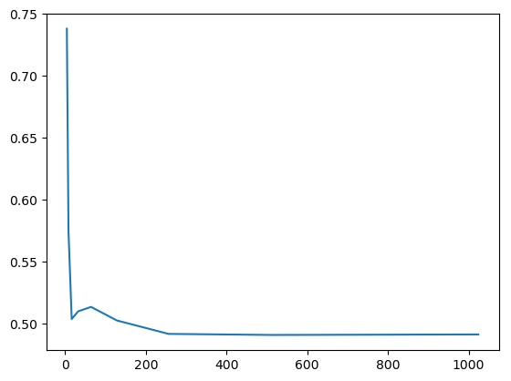

```
For num_phrases = 4, the length of codewords per average number of symbols is 0.7380073800738006.
For num_phrases = 8, the length of codewords per average number of symbols is 0.5750397112840617.
For num_phrases = 16, the length of codewords per average number of symbols is 0.5037092723257128.
For num_phrases = 32, the length of codewords per average number of symbols is 0.509938600712527.
For num_phrases = 64, the length of codewords per average number of symbols is 0.5134824236903565.
For num_phrases = 128, the length of codewords per average number of symbols is 0.5025554332592242.
For num_phrases = 256, the length of codewords per average number of symbols is 0.4917191965145663.
For num_phrases = 512, the length of codewords per average number of symbols is 0.4908662679449177.
For num_phrases = 1024, the length of codewords per average number of symbols is 0.49127881871156076.
```

```
1-element Array{Any,1}:
 PyObject <matplotlib.lines.Line2D object at 0x7f678ee31050>
```

```julia
src_pmf = [0.9, 0.1]
avg_lengths = zeros(10)
for k = 2:10
    phrases, pmf = Tunstall(src_pmf, 2^k)
    len_codewords = log2(length(phrases))
    avg_len_phrases = avgLength(phrases, pmf)
    avg_lengths[k] = len_codewords/avg_len_phrases
    print("For num_phrases = ", 2^k, ", the length of codewords per average number of symbols is ", avg_lengths[k], ".\n")
end
plot(map(x -> 2^x, 2:10), avg_lengths[2:10])
```

Note that the entropy of the source pmf is

```julia
entropy(src_pmf)
```

```
0.46899559358928133
```

#### (b) For $\texttt{src\_pmf} = \{p,1-p\}$, plot the length of codewords per average number of symbols for $\texttt{num\_phrases}=1024$ as a function of $p$. The plot should be evaluated at 100 values of $p$.

```julia
num_phrases = 1024
plist = collect(0.01:0.01:0.99)
avg_lengths_Tunstall = zeros(length(plist))
for i in 1:length(plist)
    phrases, pmf = Tunstall([plist[i], 1-plist[i]], num_phrases)
    len_codewords = log2(length(phrases))
    avg_len_phrases = avgLength(phrases, pmf)
    avg_lengths_Tunstall[i] = len_codewords/avg_len_phrases
end
```

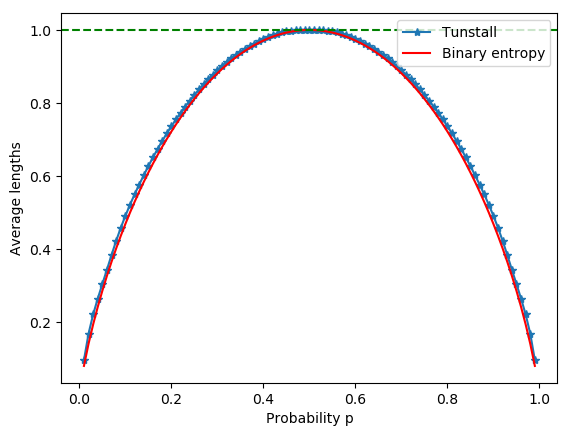

```
PyObject <matplotlib.legend.Legend object at 0x7f678ed40a90>
```

```julia
plot(plist, avg_lengths_Tunstall, marker = "*", label = "Tunstall")
plot(plist, map(x->entropy([x,1-x]), plist), color = "r", label = "Binary entropy")  # binary entropy function
axhline(1, color = "g", linestyle = "--")
xlabel("Probability p")
ylabel("Average lengths")
legend(loc = "upper right", fancybox = "true")
```

Note that the average lengths are lower bounded by the binary entropy function.

#### (c) Compare the result in part (b) with the Huffman code rate in Q4 of Homework Set #1.

Recall the last homework:

```julia
n = 10
plist = collect(0.01:0.01:0.99)
avg_lengths_Huffman = zeros(length(plist))
for i in 1:length(plist)
    pmfn = blockPmf([plist[i], 1-plist[i]], n)
    avg_lengths_Huffman[i] = avgLength(daryHuffman(pmfn, 2), pmfn)/n
end
```

Plot the results in one plot:

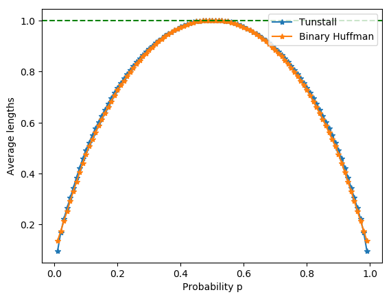

```
PyObject <matplotlib.legend.Legend object at 0x7f678ec9a750>
```

```julia
plot(plist, avg_lengths_Tunstall, marker = "*", label = "Tunstall")
plot(plist, avg_lengths_Huffman, marker = "*", label = "Binary Huffman")
axhline(1, color = "g", linestyle = "--")
xlabel("Probability p")
ylabel("Average lengths")
legend(loc = "upper right", fancybox = "true")
```